# Biostat 620 Lab 3

Author

Nate Truettner

## 1

```r
met <- read.csv("met_all.gz")
```

## 2

```r
dim(met)
```

```
[1] 2377343      30
```

```r
head(met)
```

```
  USAFID  WBAN year month day hour min  lat      lon elev wind.dir wind.dir.qc
1 690150 93121 2019     8   1    0  56 34.3 -116.166  696      220           5
2 690150 93121 2019     8   1    1  56 34.3 -116.166  696      230           5
3 690150 93121 2019     8   1    2  56 34.3 -116.166  696      230           5
4 690150 93121 2019     8   1    3  56 34.3 -116.166  696      210           5
5 690150 93121 2019     8   1    4  56 34.3 -116.166  696      120           5
6 690150 93121 2019     8   1    5  56 34.3 -116.166  696       NA           9
  wind.type.code wind.sp wind.sp.qc ceiling.ht ceiling.ht.qc ceiling.ht.method
1              N     5.7          5      22000             5                 9
2              N     8.2          5      22000             5                 9
3              N     6.7          5      22000             5                 9
4              N     5.1          5      22000             5                 9
5              N     2.1          5      22000             5                 9
6              C     0.0          5      22000             5                 9
  sky.cond vis.dist vis.dist.qc vis.var vis.var.qc temp temp.qc dew.point
1        N    16093           5       N          5 37.2       5      10.6
2        N    16093           5       N          5 35.6       5      10.6
3        N    16093           5       N          5 34.4       5       7.2
4        N    16093           5       N          5 33.3       5       5.0
5        N    16093           5       N          5 32.8       5       5.0
6        N    16093           5       N          5 31.1       5       5.6
  dew.point.qc atm.press atm.press.qc       rh
1            5    1009.9            5 19.88127
2            5    1010.3            5 21.76098
3            5    1010.6            5 18.48212
4            5    1011.6            5 16.88862
5            5    1012.7            5 17.38410
6            5    1012.7            5 20.01540
```

```r
tail(met)
```

```
        USAFID  WBAN year month day hour min    lat      lon elev wind.dir
2377338 726813 94195 2019     8  31   18  56 43.650 -116.633  741       NA
2377339 726813 94195 2019     8  31   19  56 43.650 -116.633  741       70
2377340 726813 94195 2019     8  31   20  56 43.650 -116.633  741       NA
2377341 726813 94195 2019     8  31   21  56 43.650 -116.633  741       10
2377342 726813 94195 2019     8  31   22  56 43.642 -116.636  741       10
2377343 726813 94195 2019     8  31   23  56 43.642 -116.636  741       40
        wind.dir.qc wind.type.code wind.sp wind.sp.qc ceiling.ht ceiling.ht.qc
2377338           9              C     0.0          5      22000             5
2377339           5              N     2.1          5      22000             5
2377340           9              C     0.0          5      22000             5
2377341           5              N     2.6          5      22000             5
2377342           1              N     2.1          1      22000             1
2377343           1              N     2.1          1      22000             1
        ceiling.ht.method sky.cond vis.dist vis.dist.qc vis.var vis.var.qc temp
2377338                 9        N    16093           5       N          5 30.0
2377339                 9        N    16093           5       N          5 32.2
2377340                 9        N    16093           5       N          5 33.3
2377341                 9        N    14484           5       N          5 35.0
2377342                 9        N    16093           1       9          9 34.4
2377343                 9        N    16093           1       9          9 34.4
        temp.qc dew.point dew.point.qc atm.press atm.press.qc       rh
2377338       5      11.7            5    1013.6            5 32.32509
2377339       5      12.2            5    1012.8            5 29.40686
2377340       5      12.2            5    1011.6            5 27.60422
2377341       5       9.4            5    1010.8            5 20.76325
2377342       1       9.4            1    1010.1            1 21.48631
2377343       1       9.4            1    1009.6            1 21.48631
```

The met dataset has 2,377,343 rows and 30 columns.

## 3

```r
str(met)
```

```
'data.frame':   2377343 obs. of  30 variables:
 $ USAFID           : int  690150 690150 690150 690150 690150 690150 690150 690150 690150 690150 ...
 $ WBAN             : int  93121 93121 93121 93121 93121 93121 93121 93121 93121 93121 ...
 $ year             : int  2019 2019 2019 2019 2019 2019 2019 2019 2019 2019 ...
 $ month            : int  8 8 8 8 8 8 8 8 8 8 ...
 $ day              : int  1 1 1 1 1 1 1 1 1 1 ...
 $ hour             : int  0 1 2 3 4 5 6 7 8 9 ...
 $ min              : int  56 56 56 56 56 56 56 56 56 56 ...
 $ lat              : num  34.3 34.3 34.3 34.3 34.3 34.3 34.3 34.3 34.3 34.3 ...
 $ lon              : num  -116 -116 -116 -116 -116 ...
 $ elev             : int  696 696 696 696 696 696 696 696 696 696 ...
 $ wind.dir         : int  220 230 230 210 120 NA 320 10 320 350 ...
 $ wind.dir.qc      : chr  "5" "5" "5" "5" ...
 $ wind.type.code   : chr  "N" "N" "N" "N" ...
 $ wind.sp          : num  5.7 8.2 6.7 5.1 2.1 0 1.5 2.1 2.6 1.5 ...
```

[output cut: 16 more lines]

It looks like our variables are a mix of character, numeric, and integer variables.

## 4

```r
table(met$year)
```

```
   2019
2377343
```

```r
table(met$day)
```

```
    1     2     3     4     5     6     7     8     9    10    11    12    13
75975 75923 76915 76594 76332 76734 77677 77766 75366 75450 76187 75052 76906
   14    15    16    17    18    19    20    21    22    23    24    25    26
77852 76217 78015 78219 79191 76709 75527 75786 78312 77413 76965 76806 79114
   27    28    29    30    31
79789 77059 71712 74931 74849
```

```r
table(met$hour)
```

```
     0      1      2      3      4      5      6      7      8      9     10
 99434  93482  93770  96703 110504 112128 106235 101985 100310 102915 101880
    11     12     13     14     15     16     17     18     19     20     21
100470 103605  97004  96507  97635  94942  94184 100179  94604  94928  96070
    22     23
 94046  93823
```

```r
table(met$month)
```

```
      8
2377343
```

```r
summary(met$temp)
```

```
   Min. 1st Qu.  Median    Mean 3rd Qu.    Max.    NA's
 -40.00   19.60   23.50   23.59   27.80   56.00   60089
```

```r
summary(met$elev)
```

```
   Min. 1st Qu.  Median    Mean 3rd Qu.    Max.
  -13.0   101.0   252.0   415.8   400.0  9999.0
```

```r
summary(met$wind.sp)
```

```
   Min. 1st Qu.  Median    Mean 3rd Qu.    Max.    NA's
  0.000   0.000   2.100   2.459   3.600  36.000   79693
```

It looks like all of the observations were taken in August 2019 at various points throughout the day. Examining temperature, we see there is an extreme minimum observation (-40 C); I think this could be a mistake. The wind speed and temperature variables have a lot of NA entries. The 9999 elevation value should be removed as well.

```r
# Replace elevations of 9999 with NA
library(dplyr)
met <- met %>%
  mutate(elev = na_if(elev, 9999))

summary(met$elev)
```

```
   Min. 1st Qu.  Median    Mean 3rd Qu.    Max.    NA's
    -13     101     252     413     400    4113     710
```

After removing the anomalous elevation, we see that the maximum elevation station is located 4113 meters above sea level.

```r
# Remove anomalous temperature observations
met <- met %>%
  mutate(temp = na_if(temp, -40))
met <- met %>%
  filter(!is.na(temp))
summary(met$temp)
```

```
   Min. 1st Qu.  Median    Mean 3rd Qu.    Max.
 -17.20   19.60   23.50   23.59   27.80   56.00
```

The minimum temperature recorded is now -17.2 degrees Celsius, which is still very low and warrants investigation.

## 5

```r
summary(met$elev)
```

```
   Min. 1st Qu.  Median    Mean 3rd Qu.    Max.    NA's
  -13.0   101.0   252.0   414.3   400.0  4113.0     182
```

The minimum elevation of 13 meters below sea level is reasonable, and 4113 meters above is high but also reasonable. The location (38.8, -104.3) has some very low temperature readings, -17.2 and -17 degrees Celsius. This location is actually Ellicott, Colorado, and it would be very shocking if it was actually -17 degrees Celsius there in August, so these values should be removed. We also have observations of -17 degrees in Texas in August, so those should be removed as well.

```r
met <- met %>%
  mutate(temp = na_if(temp, -17.2))
met <- met %>%
  mutate(temp = na_if(temp, -17))
met <- met %>%
  filter(!is.na(temp))
```

## 6

```r
max_elevation = max(met$elev, na.rm = TRUE)
high_station <- filter(met,
                       elev == max_elevation)

summary(high_station$wind.sp)
```

```
   Min. 1st Qu.  Median    Mean 3rd Qu.    Max.    NA's
  0.000   4.100   6.700   7.245   9.800  21.100     168
```

```r
summary(high_station$temp)
```

```
   Min. 1st Qu.  Median    Mean 3rd Qu.    Max.
   1.00    6.00    8.00    8.13   10.00   15.00
```

```r
#Temperature and wind speed
cor(high_station$temp, high_station$wind.sp, use = "complete.obs")
```

```
[1] -0.09373843
```

```r
#Temperature and hour
cor(high_station$hour, high_station$temp, use = "complete.obs")
```

```
[1] 0.4397261
```

```r
#Temperature and day
cor(high_station$day, high_station$temp, use = "complete.obs")
```

```
[1] -0.003857766
```

```r
#Wind speed and hour
cor(high_station$hour, high_station$wind.sp, use = "complete.obs")
```

```
[1] 0.08807315
```

```r
#Wind speed and day
cor(high_station$day, high_station$wind.sp, use = "complete.obs")
```

```
[1] 0.3643079
```

We notice that temperature and wind speed both increase throughout the day, while wind speed increases as the month goes on and temperature decreases. A higher temperature is correlated with a lower wind speed, which makes sense.

## 7

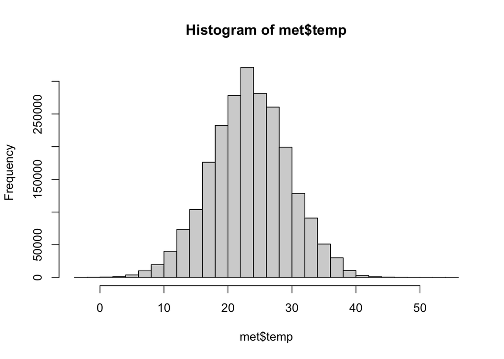

```r
hist(met$temp)
```

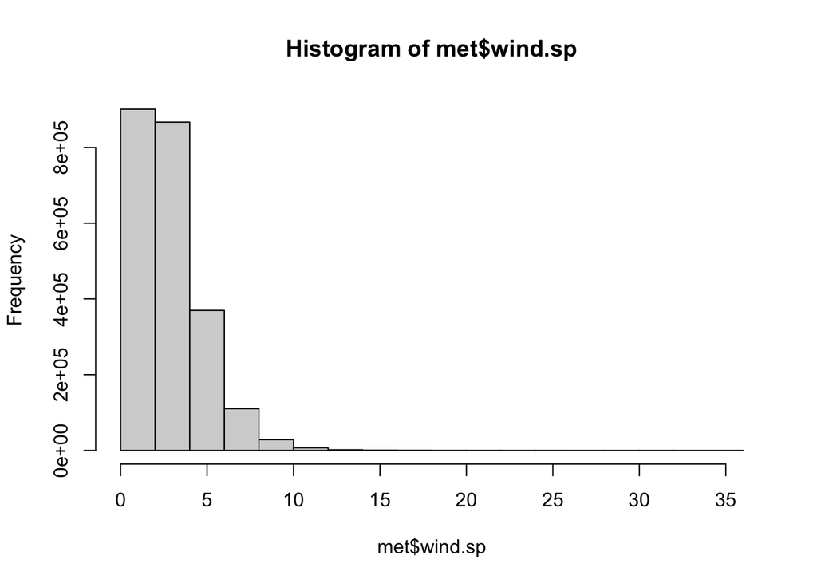

```r
hist(met$wind.sp)
```

```r
summary(met$wind.sp)
```

```
   Min. 1st Qu.  Median    Mean 3rd Qu.    Max.    NA's
  0.000   0.000   2.100   2.462   3.600  36.000   31743
```

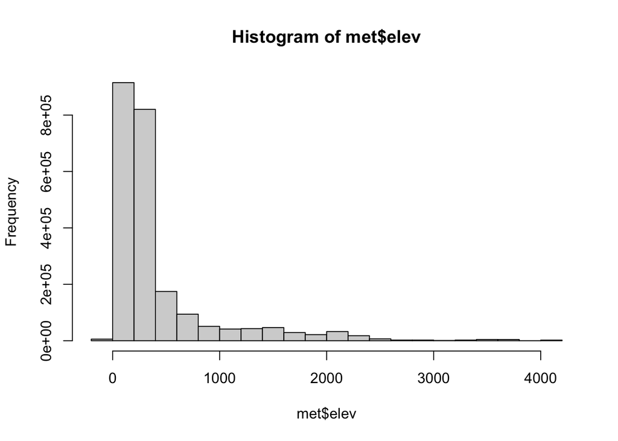

```r
hist(met$elev)
```

All three variables look good.

```r
library(leaflet)
leaflet(high_station) %>%
  addProviderTiles('OpenStreetMap') %>%
  addCircles(lat=~lat,lng=~lon, opacity=1, fillOpacity=1, radius=100)
```

[interactive chart not shown]

The highest elevation station is just west of Denver, in the mountains.

```r
library(lubridate)
high_station$date <- with(high_station, ymd_h(paste(year, month, day, hour, sep= ' ')))
summary(high_station$date)
```

```
                 Min.               1st Qu.                Median
"2019-08-01 00:00:00" "2019-08-08 11:00:00" "2019-08-16 22:00:00"
                 Mean               3rd Qu.                  Max.
"2019-08-16 14:09:56" "2019-08-24 11:00:00" "2019-08-31 22:00:00"
```

```r
high_station <- high_station[order(high_station$date), ]
head(high_station)
```

```
  USAFID WBAN year month day hour min  lat      lon elev wind.dir wind.dir.qc
1 720385  419 2019     8   1    0  36 39.8 -105.766 4113      170           5
2 720385  419 2019     8   1    0  54 39.8 -105.766 4113      100           5
3 720385  419 2019     8   1    1  12 39.8 -105.766 4113       90           5
4 720385  419 2019     8   1    1  35 39.8 -105.766 4113      110           5
5 720385  419 2019     8   1    1  53 39.8 -105.766 4113      120           5
6 720385  419 2019     8   1    2  12 39.8 -105.766 4113      120           5
  wind.type.code wind.sp wind.sp.qc ceiling.ht ceiling.ht.qc ceiling.ht.method
1              N     8.8          5       1372             5                 M
2              N     2.6          5       1372             5                 M
3              N     3.1          5       1981             5                 M
4              N     4.1          5       2134             5                 M
5              N     4.6          5       2134             5                 M
6              N     6.2          5      22000             5                 9
  sky.cond vis.dist vis.dist.qc vis.var vis.var.qc temp temp.qc dew.point
1        N       NA           9       N          5    9       5         1
2        N       NA           9       N          5    9       5         1
3        N       NA           9       N          5    9       5         2
4        N       NA           9       N          5    9       5         2
5        N       NA           9       N          5    9       5         2
6        N       NA           9       N          5    9       5         2
  dew.point.qc atm.press atm.press.qc       rh                date
1            5        NA            9 57.61039 2019-08-01 00:00:00
2            5        NA            9 57.61039 2019-08-01 00:00:00
3            5        NA            9 61.85243 2019-08-01 01:00:00
4            5        NA            9 61.85243 2019-08-01 01:00:00
5            5        NA            9 61.85243 2019-08-01 01:00:00
6            5        NA            9 61.85243 2019-08-01 02:00:00
```

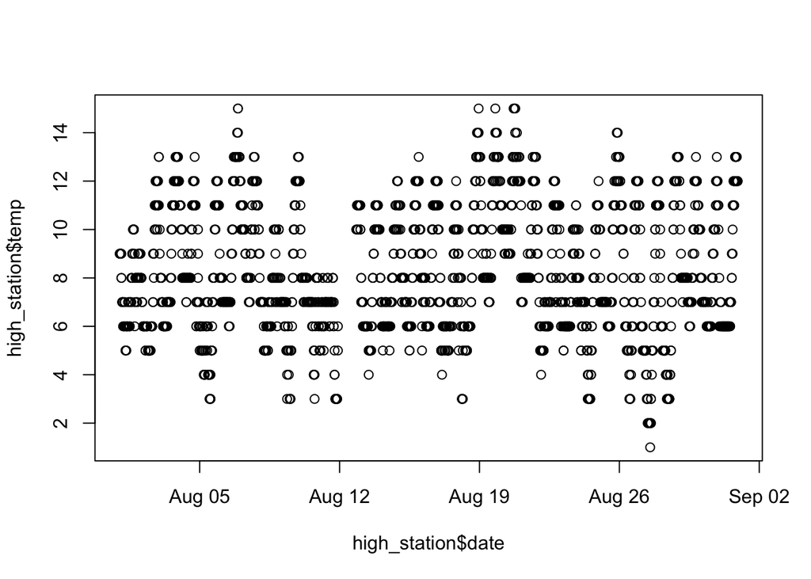

```r
plot(high_station$date, high_station$temp)
```

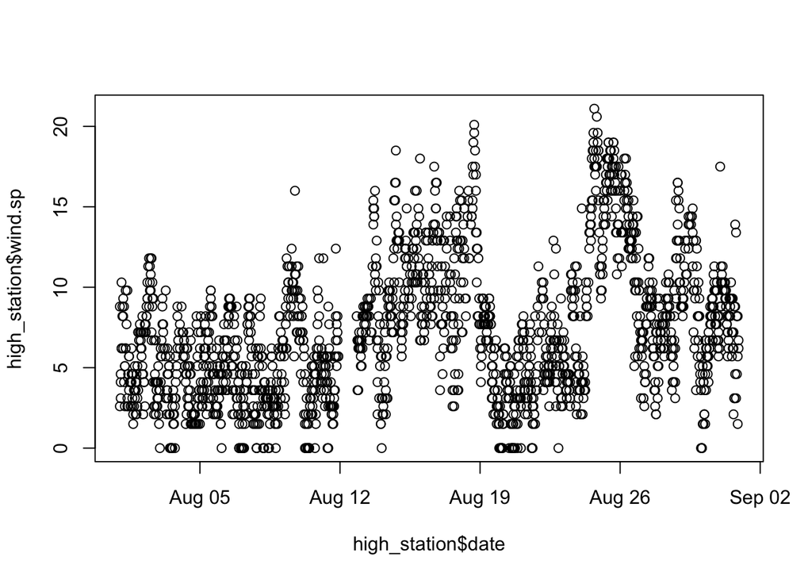

```r
plot(high_station$date, high_station$wind.sp)
```

Examining these time series plots, we see fluctuations in both temperature and wind speed as time passes. Temperature has large fluctuations within days, which makes sense as it cools down at night. Generally, high temperatures are consistent through the month. Wind speed is generally lower earlier in August and increases later in the month, but this varies quite a bit as well.

## 8

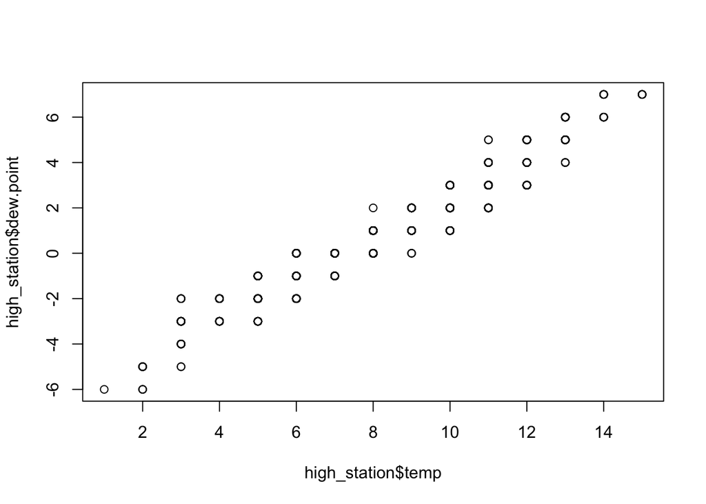

```r
plot(high_station$temp, high_station$dew.point)
```

Continuing my focus on the highest elevation station, I wanted to plot the relationship between temperature and dew point. Typically, dew point will rise with temperature provided that there is moisture added, and we see that relationship hold true in the plot.

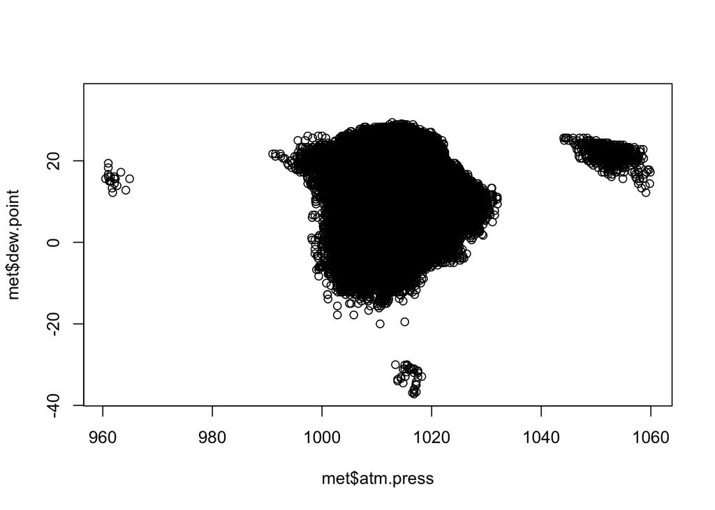

```r
plot(met$atm.press, met$dew.point)
```

I also know that pressure and dew point have a relationship, but it’s never been clear to me what the specific mechanism is. I plotted atmospheric pressure against dew point for the full dataset and found some interesting results; there is a large clump of pressures between 1000 and 1020 with a wide range of dew points. There doesn’t appear to be a clear positive or negative relationship between the variables.